# HW2: Basic tidyverse

## Repo admin

From the first homework assignment, you should now have a `Homework` folder on your computer containing a subfolder `HW1` with the first assignment. For the coming assignments, you will need data that is made available in the repo at [`https://github.com/MT5013-HT18/HW_data`](https://github.com/MT5013-HT18/HW_data). Clone this repo (by creating a new R-project) into a subfolder `HW_data` of `Homework`. We recommend that you start a fresh R-project in `Homework/HW2`, but communicate with GitHub through the project in `Homework` (i.e. open this project when you need to commit/push).

### Summary of repos and folders

- The `Homework` folder is connected to your `HW_username` repository on GitHub. When you want to push your work to GitHub, open the R-project in this folder and commit-push. It has a subfolder `Homework/HW_data` and one subfolder for each homework (`Homework/HW1`, `Homework/HW2`, …). It also contains the `README.md`-file where you insert links to your homeworks.
- The `Homework/HW_data` folder is connected to `https://github.com/MT5013-HT18/HW_data`. When a new homework is issued, you need to open the R-project in this folder and pull new data from GitHub. You should never change the files in this folder. If you do so by mistake, delete it and make a new clone.
- The `Homework/HWX` folders. This is where you keep your code for each homework. You should keep a separate R-project in each, but these need not be under version control.

### Finally

You should not push the `Homework/HW_data` to GitHub. In order to avoid this:

- Open the R-project in `Homework`.
- Choose “Open file…” and open the file `.gitignore` (a list of files that git ignores).
- Add a new line containing `HW_data` and save the file.

# HW instructions

Solutions to the following tasks should be presented in an R-Markdown document with `output: github_document`. Both the R-Markdown document (.Rmd-file) and the compiled Markdown document (.md file), as well as any figures needed for properly rendering the Markdown file on GitHub. Code should be written clearly in a consistent style, see e.g. [Google’s R Style guide](https://google.github.io/styleguide/Rguide.xml) or [Hadley Wickham’s style guide](http://adv-r.had.co.nz/Style.html).

Your submitted code should be self-contained and results reproducible for someone having access to the `HW_data`-repo. It is not mandatory to use the tidyverse, but code should be easily readable and avoid unnecessary repetition of variable names.

# Birdwatching

At [Artportalen](https://www.artportalen.se/) you can register your sightings of animals, plants or mushrooms. In this task you should analyse sightings recorded in Stockholm during January to October 2018, downloaded from [The Analysis portal for biodiversity data](https://www.analysisportal.se/). We will focus on birds, since they are by far the most popular to report.

A glimpse of data is given by

```r
library(tidyverse)
species_data <- read_csv("../HW_data/SpeciesObservations-2018-11-07-14-23-54.csv")
glimpse(species_data)
```

```
## Observations: 55,374
## Variables: 16
## $ `Scientific name`            <chr> "Lepus europaeus", "Larus fuscus"...
## $ `Common name`                <chr> "fälthare", "silltrut", "silltrut...
## $ `Organism group`             <chr> "Däggdjur", "Fåglar", "Fåglar", "...
## $ `Occurrence status`          <chr> "Present", "Present", "Present", ...
## $ `Recorded by`                <chr> "Henry Gudmundson", "Pär Grönhage...
## $ Locality                     <chr> "Brännkyrka sn, Enskedefältet", "...
## $ County                       <chr> "Stockholm", "Stockholm", "Stockh...
## $ `Coordinate uncertainty (m)` <int> 10, 1962, 1962, 10, 70, 70, 70, 7...
## $ X                            <int> 2010152, 2004678, 2004678, 200669...
## $ Y                            <int> 8242684, 8243673, 8243673, 824922...
## $ Start                        <chr> "06/04/2018", "29/03/2018", "24/0...
## $ End                          <chr> "06/04/2018", "29/03/2018", "24/0...
## $ Dataset                      <chr> "Species Observations System (Art...
## $ `Uncertain determination`    <chr> "False", "False", "False", "False...
## $ Identification               <chr> "Unvalidated", "Unvalidated", "Un...
## $ ObservationId                <int> 113645773, 113482322, 115220647, ...
```

If the file can’t be found, then you are not in the `HW2` R-project or you did not follow the above instructions. In general, TAB-completion in RStudio is very useful for accessing files; write `read_csv("")`, place your cursor between the citation marks and press the TAB key.

## Data cleaning

There are a few things we would like to fix initially:

- Some variable names contains spaces, which is often inconvenient. Replace them with underscores by

```r
names(species_data) <- gsub(" ", "_", names(species_data))
```

- The `Start` and `End` variables should be of `Date`-format, not `chr` (depending on your local settings they may actually be correctly interpreted), use `as.Date` within a `mutate` to fix this. Also turn `Identification` into a `logical` variable using `as.logical`.
- Create a new variable `Date` that equals the value of `Start`, in the following this will represent the observation date.

## Tasks

- List the most recorded bird species (`Organism_group == "Fåglar"`) in January and in July (two tables with `Common_name` and number observed as columns). The function `knitr::kable` is useful for rendering tables in Markdown.
- Introduce a variable `Weekday` by applying the function `weekdays` to `Date`. Visualise the weekly activity of observers by a bar graph showing the number of bird sightings each day of the week. Make sure the bars are ordered from Monday to Sunday (see [textbook 15.4](https://r4ds.had.co.nz/factors.html#modifying-factor-order)).
- The Willow warbler (lövsångare, *Phylloscopus trochilus*) is one of the most common migratory birds in Sweden, spending winters in sub-Saharan Africa. List the first five (unique) observers (`Recorded_by`) recording a Willow warbler in Stockholm, together with the date recorded.
- Plot the monthly number of recorded lövsångare and talgoxe (`Common_name %in% c("lövsångare", "talgoxe")`) in the same figure.

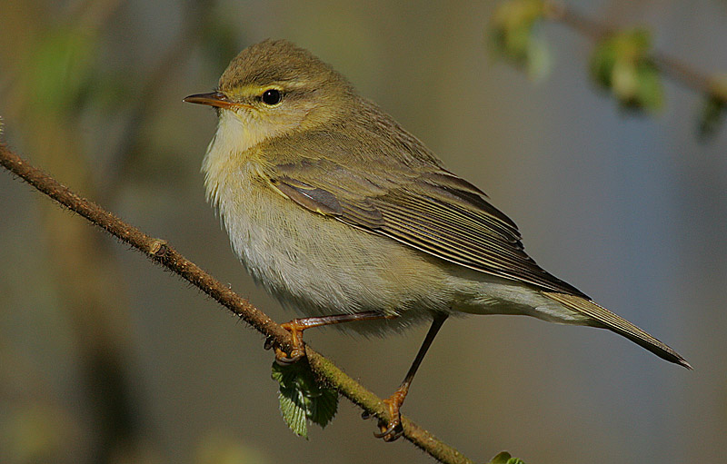

Willow warbler (Image source: Wikipedia)

# Apartment prices

The file `../HW_data/booli_sold.csv` contains sales data on 158 apartments in Ekhagen (next to Lappis) collected from [Boolis open API](https://www.booli.se/api/).

## Tasks

- Illustrate how `Soldprice` depends on `Livingarea` with a suitable figure.
- Illustrate trends in `Soldprice / Livingarea` over the period.
- Illustrate an aspect of data using a table.
- Illustrate an aspect of data using a histogram.
- Illustrate an aspect of data using a boxplot (`geom_boxplot`).